# A Decade of SERJ

Patterns, Methods, and Future Directions in Statistics Education Research

Alyssa Hu

6 October 2026

## Collaborators

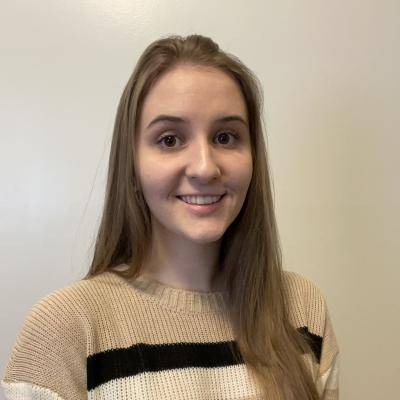

Abby L. Sine

**Abby L. Sine**

Penn State University

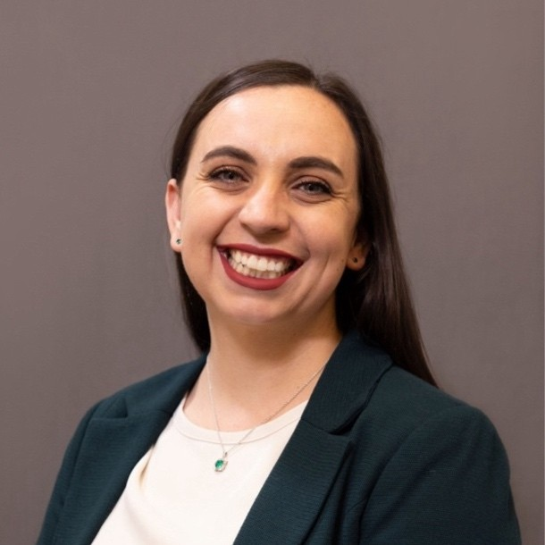

Emilee A. Herman

**Emilee A. Herman**

San Juan College

[figure not shown]

Kaitlyn R. Fales

**Kaitlyn R. Fales**

Root Inc.

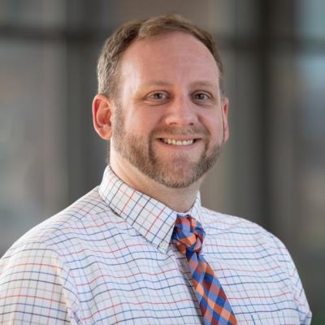

Neil J. Hatfield

**Neil J. Hatfield**

Penn State University

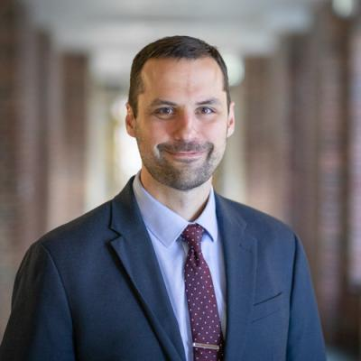

Matthew D. Beckman

**Matthew D. Beckman**

Penn State University

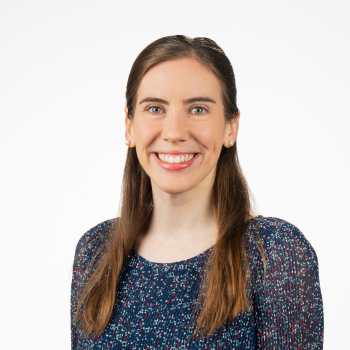

Susan E. Lloyd

**Susan E. Lloyd**

Bucknell University

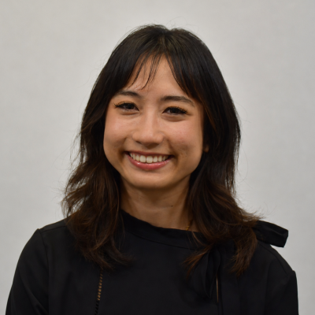

Emi Cervantes

**Emi Cervantes**

Penn State University

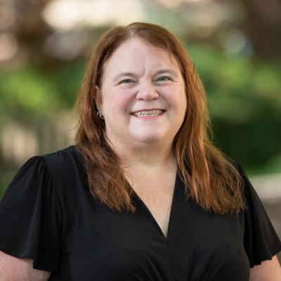

Marjorie Bond

**Marjorie Bond**

Penn State University

## Why review SERJ?

**SERJ = Statistics Education Research Journal**

Approaching its 25th anniversary in **2027**

Our review examines the journal’s published articles, extending an earlier review.

**Zieffler et al. (2011)**

2002–2009 · **72 articles**

→

**Our review**

2013–2024 · **242 articles**

If you’re looking for a quick tour of what statistics education research might look like, this talk is for you.

## Which articles are included?

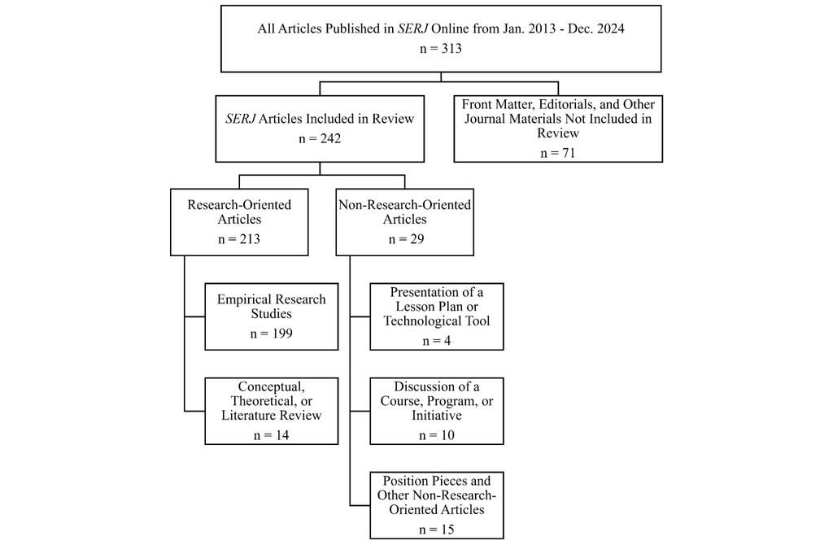

## Building on the earlier review

| Earlier review categories: | Data collected | Our review categories: | Data collected |
| --- | --- | --- | --- |
| Who says | Collaborations (single or multiple authors, interdisciplinary and/or international collaborations) Primary author(s), and the author’s department, institution, country | Authorship | Collaborations (single or multiple authors, interdisciplinary and/or international collaborations) The listed author(s) The primary affiliation listed for the author(s) (department, institution, count… |
| What | Research questions/goals Article topics Article keywords | Research Question / Purpose Abstract and Keywords | Research question(s) / aim(s) / goal(s) Research question topics Article abstract Article keywords |

## Expanding what we collect

| Earlier review: question | Data collected | Our review: component | Data collected |
| --- | --- | --- | --- |
| Why | References cited | Theoretical Framework | Theoretical framework / model / perspective References pertaining to educational / learning theories |
| To Whom | Populations being studied | Participants | Populations being studied Participant demographics |
| To What Extent and What Effect | Research classification Constructs/Instruments Research methods | Methodology | Type of paper (e.g., empirical research study) Methods (quantitative, qualitative, mixed) Mechanisms for data collection Artifacts for data analysis Analysis procedures Availability of data / code / c… |
|  |  | Discussion/Study Implications | Implications (research and/or teaching) |

## From articles to codes

**Independent review**

Two coders read and code the same article

→

**Compare**

Identify where coding differs

→

**Return to the paper**

Recheck the text and evidence

→

**Reconcile**

Agree on the final code used in the dataset

**Coding form**

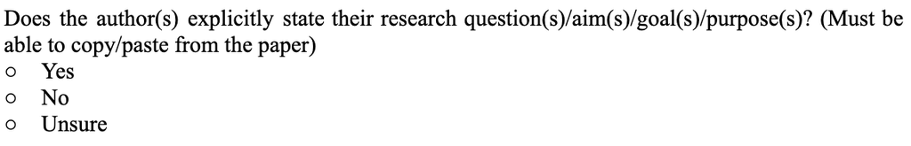

**Written guidelines**

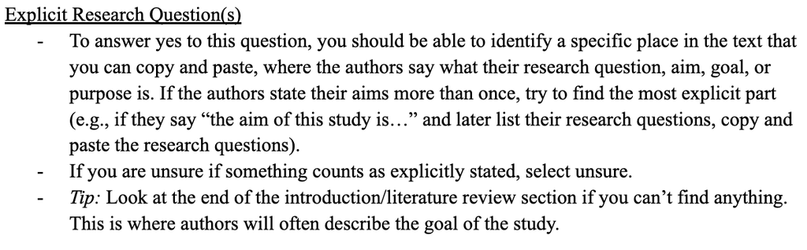

**Codebook and guidelines**

This is an example of what the coder will see during article review.

## Where are SERJ authors based?

**45 countries represented** · **516 unique authors** · **207 unique first authors**

**All authors**

| Country affiliation | Frequency |
| --- | --- |
| USA | 235 |
| Australia | 58 |
| Brazil | 58 |
| Germany | 32 |
| Canada | 31 |
| New Zealand | 26 |
| UK | 25 |
| Spain | 19 |
| Argentina | 14 |
| Israel | 14 |

**First authors**

| Country affiliation | Frequency |
| --- | --- |
| USA | 82 |
| Brazil | 23 |
| Australia | 22 |
| Germany | 13 |
| UK | 10 |
| Canada | 9 |
| New Zealand | 9 |
| Spain | 7 |
| Israel | 7 |
| Sweden | 7 |

Across 242 articles included in review

## Research in SERJ tends to be collaborative

**79%** of the 242 articles had multiple authors

**192** multiple-author

**50** single-author

Authors per article: **mean 2.7** · **median 2** · **maximum 8**

**111 articles** involved cross-institutional collaboration

58% of the 192 multiple-author articles

**43 of those 111** involved international collaboration

## What topics do the articles investigate?

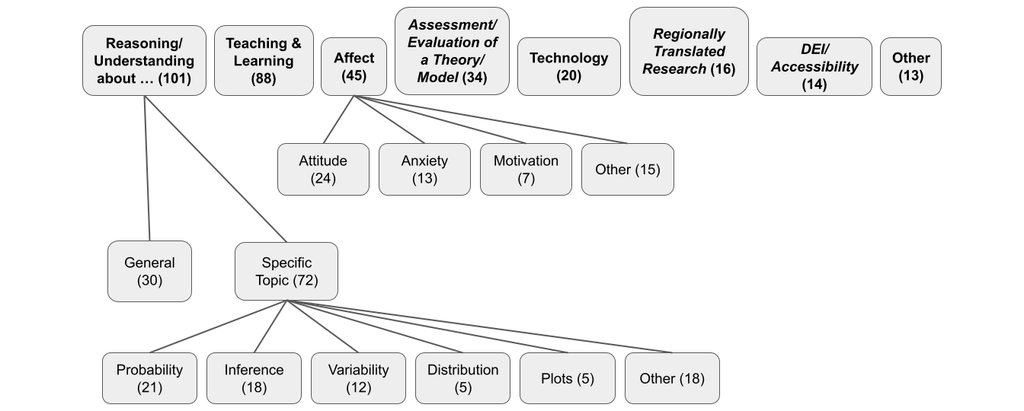

Across 213 research-oriented articles · An article may address multiple topics

## Who is studied?

| Population | Frequency |
| --- | --- |
| Undergraduate Students | 76 |
| Pre-K-12 Students | 62 |
| In-Service Teachers | 23 |
| Graduate/Professional Students | 21 |
| Pre-service Teachers | 18 |
| Literature Review | 10 |
| Post-secondary Educators | 8 |
| Textbooks, Courses, or Other Course Artifacts | 7 |
| Industry Professionals | 4 |
| Not Applicable/Theoretical | 2 |
| Non-student Adults | 1 |
| Non-traditional Students (secondary) | 1 |

Across 213 research-oriented articles · An article may include multiple populations

## How do researchers collect their data?

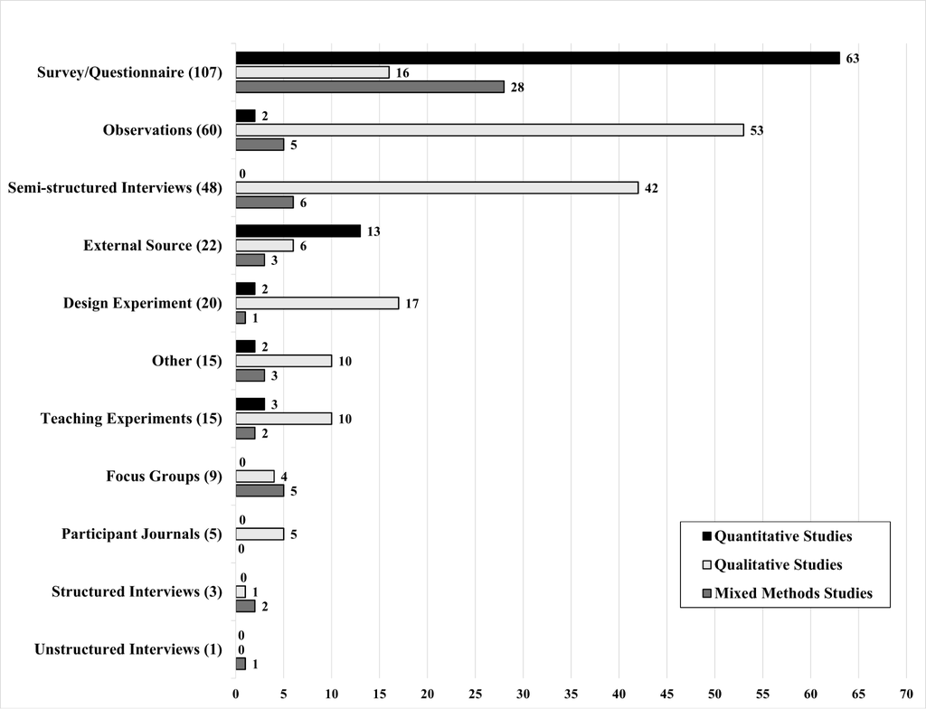

Across 199 empirical articles · An article may use multiple collection methods

## How easy is the research to follow and build on?

**Reuse and reproducibility**

**195 / 199** empirical articles: no data access identified

**119 / 199**: no study materials identified

Qualitative analysis methods were sometimes not explicitly named

**Implications**

**196 / 213** research-oriented articles had explicit implications for teaching and/or research

Often scattered across results, discussion, limitations or conclusions

The issue was often not whether the contribution existed, but how explicitly it was communicated.

## What would strengthen future research?

These directions draw on the full review, not only the selected findings shown here.

**Ground the work**

Clarify how theory informs research questions, design and analysis

Develop statistics-education-specific frameworks where useful

**Broaden the evidence base**

Attend to whose experiences and contexts are represented

Report demographics and context so readers can judge generalisability

**Make the work easier to build on**

Be explicit about methods and implications

Share data, instruments, materials and code where feasible

## Thank you! Any questions?

**Slides available at:**

[figure not shown]

**Preprint:**

**Link forthcoming**